# Data Prep

**Purpose: Structural cleaning + EDA + rule definition**

**Is the dataset coherent and what rules will we apply?**

Contains:

- Raw data loading
- Sample alignment
- Structural QC
- Missingness analysis
- Distribution checks
- Cohort definition
- Explicit filtering rules (constants)

```python
import pandas as pd
import matplotlib.pyplot as plt
from matplotlib.colors import ListedColormap
import seaborn as sns
import numpy as np
from sklearn.decomposition import PCA
from sklearn.preprocessing import StandardScaler
```

```python
# Load data

RAW_DIR = "../data/raw"

rna_path = f"{RAW_DIR}/TCGA-BRCA.star_tpm.tsv.gz"
clin_path = f"{RAW_DIR}/TCGA-BRCA.clinical.tsv.gz"
surv_path = f"{RAW_DIR}/TCGA-BRCA.survival.tsv.gz"

# Load
rna_raw_df = pd.read_csv(rna_path, sep="\t")
clin_raw_df = pd.read_csv(clin_path, sep="\t")
surv_raw_df = pd.read_csv(surv_path, sep="\t")
```

## EDA and Initial Cleaning

#### Avoiding label and distribution leakage

- Care must be taken when filtering the full dataset prior to the train / test split.
- Pre-split filtering must be based on data validity and structural integrity (e.g., duplicate samples, failed QC, missing core modalities, corrupted values), not on distributional convenience or model behavior.
- Any filtering influenced by outcome labels or survival-related structure (including removing statistical outliers that affect class balance or separation) must be done after the train / test split and fit on the training set only.
- Statistical transformations or feature selection steps (e.g., variance filtering, scaling, PCA for modeling) must be fit using training data only and then applied to validation/test data.

#### Feature validity versus salience filtering

**Validity filtering (allowed pre-split)**

- We are asking:
  - Is this feature even a legitimate, usable variable?
- Examples:
  - All missing
  - Constant
  - ID column
  - Survival timing field (leakage)
  - 80% missing and unusable in practice
- We are not asking whether it predicts survival.

**Salience filtering (must be train-only)**

- We are asking:
  - Is this feature informative or useful for prediction?
- Examples:
  - High variance genes
  - Correlated with survival
  - Strong mutual information
  - Selected by lasso
  - PCA components
- This is about signal strength, which depends on distribution. That must be estimated from training data only.
- Even if unsupervised (e.g., variance filtering), salience filtering uses dataset-level distributional information and therefore must be fit on training data only.

### Structural sanity checks

```python
# Check

# Shapes
print("RNA shape:", rna_raw_df.shape)
print("Clinical shape:", clin_raw_df.shape)
print("Survival shape:", surv_raw_df.shape)

# Peek at columns / headers
print("\nRNA head, tail:")
display(rna_raw_df.head())
display(rna_raw_df.tail())

print("\nClinical head, tail:")
display(clin_raw_df.head())
display(clin_raw_df.tail())

print("\nSurvival head, tail:")
display(surv_raw_df.head())
display(surv_raw_df.tail())
```

```
RNA shape: (60660, 1227)
Clinical shape: (1255, 85)
Survival shape: (1232, 4)

RNA head, tail:
```

|  | Ensembl_ID | TCGA-D8-A146-01A | TCGA-AQ-A0Y5-01A | TCGA-C8-A274-01A | TCGA-BH-A0BD-01A | TCGA-B6-A1KC-01B | TCGA-AC-A62V-01A | TCGA-AO-A0J5-01A | TCGA-BH-A0B1-01A | TCGA-A2-A0YM-01A | ... | TCGA-E2-A1IG-01A | TCGA-E9-A1NA-01A | TCGA-D8-A1JP-01A | TCGA-AR-A252-01A | TCGA-D8-A1XL-01A | TCGA-BH-A0EI-01A | TCGA-E2-A1IO-01A | TCGA-E2-A15R-01A | TCGA-B6-A0IP-01A | TCGA-A1-A0SN-01A |
| --- | --- | --- | --- | --- | --- | --- | --- | --- | --- | --- | --- | --- | --- | --- | --- | --- | --- | --- | --- | --- | --- |
| 0 | ENSG00000000003.15 | 5.662037 | 3.703721 | 6.514515 | 4.784917 | 4.251984 | 3.536849 | 4.645690 | 6.021755 | 6.260931 | ... | 4.825501 | 4.142806 | 4.960919 | 4.770121 | 5.276757 | 6.436490 | 6.184500 | 2.670931 | 6.834395 | 3.650719 |
| 1 | ENSG00000000005.6 | 3.376096 | 0.463099 | 0.000000 | 2.328061 | 0.435415 | 0.736475 | 1.255622 | 0.392647 | 0.467593 | ... | 0.134747 | 0.159500 | 0.079566 | 3.312418 | 0.000000 | 0.383608 | 0.755144 | 0.479644 | 0.526069 | 0.059909 |
| 2 | ENSG00000000419.13 | 6.860140 | 7.086452 | 6.805072 | 6.443071 | 6.178436 | 6.823355 | 5.749910 | 6.977449 | 6.819887 | ... | 6.382933 | 6.436308 | 6.994589 | 6.005000 | 7.382161 | 7.220846 | 6.868277 | 7.033110 | 6.384368 | 8.153019 |
| 3 | ENSG00000000457.14 | 4.400552 | 4.051007 | 5.037264 | 4.374970 | 3.558464 | 2.108324 | 4.487107 | 4.021000 | 3.319560 | ... | 3.891448 | 3.765057 | 4.946796 | 3.648707 | 3.664915 | 3.752192 | 4.093078 | 4.831796 | 4.368028 | 4.172247 |
| 4 | ENSG00000000460.17 | 2.845169 | 2.426989 | 4.043248 | 4.162790 | 2.589548 | 2.277777 | 2.545178 | 3.372492 | 4.023974 | ... | 2.557655 | 2.566596 | 3.746915 | 2.494160 | 3.104957 | 3.111549 | 2.538538 | 3.730901 | 3.311721 | 3.301075 |

5 rows × 1227 columns

|  | Ensembl_ID | TCGA-D8-A146-01A | TCGA-AQ-A0Y5-01A | TCGA-C8-A274-01A | TCGA-BH-A0BD-01A | TCGA-B6-A1KC-01B | TCGA-AC-A62V-01A | TCGA-AO-A0J5-01A | TCGA-BH-A0B1-01A | TCGA-A2-A0YM-01A | ... | TCGA-E2-A1IG-01A | TCGA-E9-A1NA-01A | TCGA-D8-A1JP-01A | TCGA-AR-A252-01A | TCGA-D8-A1XL-01A | TCGA-BH-A0EI-01A | TCGA-E2-A1IO-01A | TCGA-E2-A15R-01A | TCGA-B6-A0IP-01A | TCGA-A1-A0SN-01A |
| --- | --- | --- | --- | --- | --- | --- | --- | --- | --- | --- | --- | --- | --- | --- | --- | --- | --- | --- | --- | --- | --- |
| 60655 | ENSG00000288669.1 | 0.000000 | 0.000000 | 0.000000 | 0.000000 | 0.000000 | 0.000000 | 0.000000 | 0.000000 | 0.022474 | ... | 0.000000 | 0.000000 | 0.000000 | 0.000000 | 0.000000 | 0.000000 | 0.000000 | 0.000000 | 0.000000 | 0.022474 |
| 60656 | ENSG00000288670.1 | 3.533999 | 4.773448 | 4.701710 | 4.689075 | 5.168221 | 3.140910 | 3.471331 | 4.392331 | 4.234333 | ... | 4.779218 | 2.971737 | 4.466268 | 3.122010 | 3.721318 | 4.015756 | 3.535331 | 5.303605 | 4.490782 | 3.528471 |
| 60657 | ENSG00000288671.1 | 0.000000 | 0.000000 | 0.000000 | 0.000000 | 0.000000 | 0.000000 | 0.000000 | 0.000000 | 0.000000 | ... | 0.000000 | 0.000000 | 0.000000 | 0.000000 | 0.000000 | 0.000000 | 0.000000 | 0.000000 | 0.000000 | 0.000000 |
| 60658 | ENSG00000288674.1 | 0.058109 | 0.054779 | 0.093425 | 0.059771 | 0.023752 | 0.071900 | 0.051581 | 0.048655 | 0.055473 | ... | 0.032101 | 0.059217 | 0.037171 | 0.047678 | 0.023042 | 0.044324 | 0.074231 | 0.028852 | 0.122076 | 0.073272 |
| 60659 | ENSG00000288675.1 | 1.122739 | 1.243182 | 0.604261 | 0.536351 | 0.389126 | 1.212071 | 1.049979 | 0.436482 | 0.709467 | ... | 0.991898 | 0.969970 | 0.630033 | 0.866631 | 1.342100 | 1.381560 | 0.864018 | 1.688538 | 0.699996 | 0.640899 |

5 rows × 1227 columns

```
Clinical head, tail:
```

|  | sample | id | disease_type | case_id | submitter_id | primary_site | alcohol_history.exposures | race.demographic | gender.demographic | ethnicity.demographic | ... | days_to_collection.samples | initial_weight.samples | preservation_method.samples | pathology_report_uuid.samples | oct_embedded.samples | specimen_type.samples | days_to_sample_procurement.samples | is_ffpe.samples | tissue_type.samples | annotations.samples |
| --- | --- | --- | --- | --- | --- | --- | --- | --- | --- | --- | --- | --- | --- | --- | --- | --- | --- | --- | --- | --- | --- |
| 0 | TCGA-BH-A0W3-01A | 3c612e12-6de8-44fa-a095-805c45474821 | Ductal and Lobular Neoplasms | 3c612e12-6de8-44fa-a095-805c45474821 | TCGA-BH-A0W3 | Breast | Not Reported | white | female | not hispanic or latino | ... | 85.0 | 120.0 | OCT | 801A4E2F-E26E-424F-BF42-CD0D9CD62BCE | True | Solid Tissue | NaN | False | Tumor | NaN |
| 1 | TCGA-AR-A24V-01A | 3cb06c7a-f2a8-448b-91a8-dd201bbf2ddd | Ductal and Lobular Neoplasms | 3cb06c7a-f2a8-448b-91a8-dd201bbf2ddd | TCGA-AR-A24V | Breast | Not Reported | white | female | not hispanic or latino | ... | 1720.0 | 400.0 | OCT | 468CD293-C9F7-43C6-A40A-18FCDD22F6AA | True | Solid Tissue | NaN | False | Tumor | NaN |
| 2 | TCGA-E9-A1NE-01A | 3d676bba-154b-4d22-ab59-d4d4da051b94 | Ductal and Lobular Neoplasms | 3d676bba-154b-4d22-ab59-d4d4da051b94 | TCGA-E9-A1NE | Breast | Not Reported | white | female | not hispanic or latino | ... | 31.0 | 280.0 | OCT | CF6E29A2-FAE6-45BB-B625-33877887A89E | True | Solid Tissue | NaN | False | Tumor | NaN |
| 3 | TCGA-E9-A1NE-11A | 3d676bba-154b-4d22-ab59-d4d4da051b94 | Ductal and Lobular Neoplasms | 3d676bba-154b-4d22-ab59-d4d4da051b94 | TCGA-E9-A1NE | Breast | Not Reported | white | female | not hispanic or latino | ... | 31.0 | 830.0 | OCT | NaN | True | Solid Tissue | NaN | False | Normal | NaN |
| 4 | TCGA-AC-A8OQ-01A | dfaabd03-2d40-4422-b210-caf112ff4229 | Ductal and Lobular Neoplasms | dfaabd03-2d40-4422-b210-caf112ff4229 | TCGA-AC-A8OQ | Breast | Not Reported | black or african american | female | not hispanic or latino | ... | 742.0 | 100.0 | Unknown | FFA6F9F3-71C1-4AF9-B9F7-0466550EBC90 | False | Solid Tissue | NaN | False | Tumor | NaN |

5 rows × 85 columns

|  | sample | id | disease_type | case_id | submitter_id | primary_site | alcohol_history.exposures | race.demographic | gender.demographic | ethnicity.demographic | ... | days_to_collection.samples | initial_weight.samples | preservation_method.samples | pathology_report_uuid.samples | oct_embedded.samples | specimen_type.samples | days_to_sample_procurement.samples | is_ffpe.samples | tissue_type.samples | annotations.samples |
| --- | --- | --- | --- | --- | --- | --- | --- | --- | --- | --- | --- | --- | --- | --- | --- | --- | --- | --- | --- | --- | --- |
| 1250 | TCGA-BH-A1FH-11B | 1783cac1-253a-40af-a9ac-48dfb20e1ab8 | Ductal and Lobular Neoplasms | 1783cac1-253a-40af-a9ac-48dfb20e1ab8 | TCGA-BH-A1FH | Breast | Not Reported | white | female | not hispanic or latino | ... | 4670.0 | 280.0 | Unknown | NaN | False | Solid Tissue | NaN | False | Normal | NaN |
| 1251 | TCGA-BH-A1FH-01A | 1783cac1-253a-40af-a9ac-48dfb20e1ab8 | Ductal and Lobular Neoplasms | 1783cac1-253a-40af-a9ac-48dfb20e1ab8 | TCGA-BH-A1FH | Breast | Not Reported | white | female | not hispanic or latino | ... | 4670.0 | 430.0 | OCT | 501C3E1B-573B-4A5A-A0ED-3CD15432E6FF | True | Solid Tissue | NaN | False | Tumor | NaN |
| 1252 | TCGA-AR-A1AO-01A | 623befd6-0ca4-4a6c-9cf5-d9385c3b718f | Ductal and Lobular Neoplasms | 623befd6-0ca4-4a6c-9cf5-d9385c3b718f | TCGA-AR-A1AO | Breast | Not Reported | white | female | not hispanic or latino | ... | 1471.0 | 200.0 | OCT | 37EF1828-0A53-4358-97C7-A7849EC653AF | True | Solid Tissue | NaN | False | Tumor | NaN |
| 1253 | TCGA-A7-A0D9-01A | 17baef7c-d97d-4b98-ab53-503ef856523d | Ductal and Lobular Neoplasms | 17baef7c-d97d-4b98-ab53-503ef856523d | TCGA-A7-A0D9 | Breast | Not Reported | white | female | not hispanic or latino | ... | 173.0 | 1760.0 | Unknown | 7D5763F7-7284-4AF5-BBFC-5D8B5CB7F495 | False | Solid Tissue | NaN | False | Tumor | NaN |
| 1254 | TCGA-A7-A0D9-11A | 17baef7c-d97d-4b98-ab53-503ef856523d | Ductal and Lobular Neoplasms | 17baef7c-d97d-4b98-ab53-503ef856523d | TCGA-A7-A0D9 | Breast | Not Reported | white | female | not hispanic or latino | ... | 173.0 | 1830.0 | Unknown | NaN | False | Solid Tissue | NaN | False | Normal | NaN |

5 rows × 85 columns

```
Survival head, tail:
```

|  | sample | OS.time | OS | _PATIENT |
| --- | --- | --- | --- | --- |
| 0 | TCGA-C8-A275-01A | 1.0 | 0 | TCGA-C8-A275 |
| 1 | TCGA-AC-A7VC-01A | 1.0 | 0 | TCGA-AC-A7VC |
| 2 | TCGA-BH-A1F8-01A | 1.0 | 1 | TCGA-BH-A1F8 |
| 3 | TCGA-BH-A1F8-11B | 1.0 | 1 | TCGA-BH-A1F8 |
| 4 | TCGA-PL-A8LX-01A | 5.0 | 0 | TCGA-PL-A8LX |

|  | sample | OS.time | OS | _PATIENT |
| --- | --- | --- | --- | --- |
| 1227 | TCGA-B6-A0RE-01A | 7777.0 | 0 | TCGA-B6-A0RE |
| 1228 | TCGA-B6-A0RN-01A | 8008.0 | 0 | TCGA-B6-A0RN |
| 1229 | TCGA-B6-A0IA-01A | 8391.0 | 0 | TCGA-B6-A0IA |
| 1230 | TCGA-B6-A0I5-01A | 8556.0 | 0 | TCGA-B6-A0I5 |
| 1231 | TCGA-B6-A0RU-01A | 8605.0 | 0 | TCGA-B6-A0RU |

```python
clin_raw_df.info()
```

```
<class 'pandas.core.frame.DataFrame'>
RangeIndex: 1255 entries, 0 to 1254
Data columns (total 85 columns):
 #   Column                                                     Non-Null Count  Dtype
---  ------                                                     --------------  -----
 0   sample                                                     1255 non-null   object
 1   id                                                         1255 non-null   object
 2   disease_type                                               1255 non-null   object
 3   case_id                                                    1255 non-null   object
 4   submitter_id                                               1255 non-null   object
 5   primary_site                                               1255 non-null   object
 6   alcohol_history.exposures                                  1254 non-null   object
 7   race.demographic                                           1254 non-null   object
 8   gender.demographic                                         1254 non-null   object
 9   ethnicity.demographic                                      1254 non-null   object
```

[output cut: 77 more lines]

```python
clin_raw_df.describe().T
```

|  | count | mean | std | min | 25% | 50% | 75% | max |
| --- | --- | --- | --- | --- | --- | --- | --- | --- |
| age_at_index.demographic | 1254.0 | 58.198565 | 13.360242 | 26.000000 | 48.000000 | 58.000000 | 67.000000 | 90.000000 |
| days_to_birth.demographic | 1238.0 | -21489.376414 | 4864.993235 | -32872.000000 | -24791.000000 | -21472.000000 | -17786.000000 | -9706.000000 |
| year_of_birth.demographic | 1251.0 | 1949.451639 | 13.868405 | 1902.000000 | 1940.000000 | 1950.000000 | 1960.000000 | 1984.000000 |
| year_of_death.demographic | 147.0 | 2004.333333 | 4.046533 | 1992.000000 | 2001.000000 | 2005.000000 | 2008.000000 | 2013.000000 |
| days_to_death.demographic | 203.0 | 1586.270936 | 1237.292209 | 0.000000 | 658.500000 | 1275.000000 | 2273.000000 | 7455.000000 |
| days_to_diagnosis.diagnoses | 1254.0 | 0.000000 | 0.000000 | 0.000000 | 0.000000 | 0.000000 | 0.000000 | 0.000000 |
| days_to_last_follow_up.diagnoses | 1107.0 | 1184.824752 | 1145.193000 | -7.000000 | 441.000000 | 788.000000 | 1607.500000 | 8605.000000 |
| age_at_diagnosis.diagnoses | 1238.0 | 21489.376414 | 4864.993235 | 9706.000000 | 17786.000000 | 21472.000000 | 24791.000000 | 32872.000000 |
| year_of_diagnosis.diagnoses | 1252.0 | 2007.653355 | 4.396019 | 1988.000000 | 2006.000000 | 2009.000000 | 2010.000000 | 2013.000000 |
| age_at_earliest_diagnosis.diagnoses.xena_derived | 1238.0 | 21489.376414 | 4864.993235 | 9706.000000 | 17786.000000 | 21472.000000 | 24791.000000 | 32872.000000 |
| age_at_earliest_diagnosis_in_years.diagnoses.xena_derived | 1238.0 | 58.875004 | 13.328749 | 26.591781 | 48.728767 | 58.827397 | 67.920548 | 90.060274 |
| sample_type_id.samples | 1255.0 | 2.119522 | 3.132134 | 1.000000 | 1.000000 | 1.000000 | 1.000000 | 11.000000 |
| days_to_collection.samples | 1253.0 | 1132.055068 | 1491.389733 | 16.000000 | 157.000000 | 486.000000 | 1414.000000 | 7858.000000 |
| initial_weight.samples | 1240.0 | 312.002419 | 273.270565 | 5.000000 | 137.500000 | 220.000000 | 400.000000 | 2190.000000 |
| days_to_sample_procurement.samples | 4.0 | 0.000000 | 0.000000 | 0.000000 | 0.000000 | 0.000000 | 0.000000 | 0.000000 |

```python
surv_raw_df.describe().T
```

|  | count | mean | std | min | 25% | 50% | 75% | max |
| --- | --- | --- | --- | --- | --- | --- | --- | --- |
| OS.time | 1232.0 | 1273.177760 | 1154.554180 | 1.0 | 486.5 | 922.0 | 1734.5 | 8605.0 |
| OS | 1232.0 | 0.163149 | 0.369652 | 0.0 | 0.0 | 0.0 | 0.0 | 1.0 |

```python
with pd.option_context("display.max_rows", None):
    display(clin_raw_df.head().T)
```

|  | 0 | 1 | 2 | 3 | 4 |
| --- | --- | --- | --- | --- | --- |
| sample | TCGA-BH-A0W3-01A | TCGA-AR-A24V-01A | TCGA-E9-A1NE-01A | TCGA-E9-A1NE-11A | TCGA-AC-A8OQ-01A |
| id | 3c612e12-6de8-44fa-a095-805c45474821 | 3cb06c7a-f2a8-448b-91a8-dd201bbf2ddd | 3d676bba-154b-4d22-ab59-d4d4da051b94 | 3d676bba-154b-4d22-ab59-d4d4da051b94 | dfaabd03-2d40-4422-b210-caf112ff4229 |
| disease_type | Ductal and Lobular Neoplasms | Ductal and Lobular Neoplasms | Ductal and Lobular Neoplasms | Ductal and Lobular Neoplasms | Ductal and Lobular Neoplasms |
| case_id | 3c612e12-6de8-44fa-a095-805c45474821 | 3cb06c7a-f2a8-448b-91a8-dd201bbf2ddd | 3d676bba-154b-4d22-ab59-d4d4da051b94 | 3d676bba-154b-4d22-ab59-d4d4da051b94 | dfaabd03-2d40-4422-b210-caf112ff4229 |
| submitter_id | TCGA-BH-A0W3 | TCGA-AR-A24V | TCGA-E9-A1NE | TCGA-E9-A1NE | TCGA-AC-A8OQ |
| primary_site | Breast | Breast | Breast | Breast | Breast |
| alcohol_history.exposures | Not Reported | Not Reported | Not Reported | Not Reported | Not Reported |
| race.demographic | white | white | white | white | black or african american |
| gender.demographic | female | female | female | female | female |
| ethnicity.demographic | not hispanic or latino | not hispanic or latino | not hispanic or latino | not hispanic or latino | not hispanic or latino |
| vital_status.demographic | Alive | Alive | Alive | Alive | Alive |
| age_at_index.demographic | 58.0 | 52.0 | 28.0 | 28.0 | 72.0 |
| days_to_birth.demographic | -21369.0 | -19027.0 | -10564.0 | -10564.0 | -26535.0 |
| year_of_birth.demographic | 1952.0 | 1954.0 | 1983.0 | 1983.0 | 1939.0 |
| year_of_death.demographic | NaN | NaN | NaN | NaN | NaN |
| primary_site.project | Breast | Breast | Breast | Breast | Breast |
| project_id.project | TCGA-BRCA | TCGA-BRCA | TCGA-BRCA | TCGA-BRCA | TCGA-BRCA |
| disease_type.project | ['Squamous Cell Neoplasms', 'Adnexal and Skin ... | ['Squamous Cell Neoplasms', 'Adnexal and Skin ... | ['Squamous Cell Neoplasms', 'Adnexal and Skin ... | ['Squamous Cell Neoplasms', 'Adnexal and Skin ... | ['Squamous Cell Neoplasms', 'Adnexal and Skin ... |
| name.project | Breast Invasive Carcinoma | Breast Invasive Carcinoma | Breast Invasive Carcinoma | Breast Invasive Carcinoma | Breast Invasive Carcinoma |
| name.program.project | TCGA | TCGA | TCGA | TCGA | TCGA |
| tissue_source_site_id.tissue_source_site | ad5db77f-ce9a-53c8-b7ff-7944acf5c0c6 | 5e793cf6-1554-55db-b2ee-9c772717cea0 | 0aff4265-d73d-521d-86f3-5513571a308b | 0aff4265-d73d-521d-86f3-5513571a308b | ee04c9a8-bf82-55d9-87ba-0150284aab69 |
| code.tissue_source_site | BH | AR | E9 | E9 | AC |
| name.tissue_source_site | University of Pittsburgh | Mayo | Asterand | Asterand | International Genomics Consortium |
| project.tissue_source_site | Breast invasive carcinoma | Breast invasive carcinoma | Breast invasive carcinoma | Breast invasive carcinoma | Breast invasive carcinoma |
| bcr_id.tissue_source_site | NCH | NCH | NCH | NCH | NCH |
| days_to_death.demographic | NaN | NaN | NaN | NaN | NaN |
| entity_submitter_id.annotations | NaN | NaN | NaN | NaN | NaN |
| notes.annotations | NaN | NaN | NaN | NaN | NaN |
| submitter_id.annotations | NaN | NaN | NaN | NaN | NaN |
| classification.annotations | NaN | NaN | NaN | NaN | NaN |

[output cut: 55 more lines]

### ID alignment

#### Check sample ID intersections between the 3 datasets

```python
# Extract ID sets
clin_ids = set(clin_raw_df["sample"])
surv_ids = set(surv_raw_df["sample"])

# RNA sample IDs are column names (exclude first gene column if needed)
rna_cols = rna_raw_df.columns.tolist()

# If first column is gene identifier, drop it
if not rna_cols[0].startswith("TCGA-"):
    rna_ids = set(rna_cols[1:])
else:
    rna_ids = set(rna_cols)

print("Clinical N:", len(clin_ids))
print("Survival N:", len(surv_ids))
print("RNA N:", len(rna_ids))

print("\nClinical ∩ Survival:", len(clin_ids & surv_ids))
print("Clinical ∩ RNA:", len(clin_ids & rna_ids))
print("Survival ∩ RNA:", len(surv_ids & rna_ids))
print("All three intersect:", len(clin_ids & surv_ids & rna_ids))
```

```
Clinical N: 1255
Survival N: 1232
RNA N: 1226

Clinical ∩ Survival: 1232
Clinical ∩ RNA: 1226
Survival ∩ RNA: 1203
All three intersect: 1203
```

### Handle multiple samples per patient

```python
# How many samples per patient?
surv_raw_df["_PATIENT"].value_counts().describe()
```

```
count    1076.000000
mean        1.144981
std         0.372775
min         1.000000
25%         1.000000
50%         1.000000
75%         1.000000
max         3.000000
Name: count, dtype: float64
```

```python
# Patients with >1 sample
dup_patients = surv_raw_df["_PATIENT"].value_counts()
dup_patients = dup_patients[dup_patients > 1]

print("Patients with multiple samples:", len(dup_patients))
dup_patients.head()
```

```
Patients with multiple samples: 148
```

```
_PATIENT
TCGA-A7-A13E    3
TCGA-A7-A13G    3
TCGA-A7-A0DC    3
TCGA-BH-A1ES    3
TCGA-E2-A15K    3
Name: count, dtype: int64
```

```python
surv_raw_df[surv_raw_df.duplicated(subset="_PATIENT", keep=False)].sort_values("_PATIENT")
```

|  | sample | OS.time | OS | _PATIENT |
| --- | --- | --- | --- | --- |
| 706 | TCGA-A7-A0CE-01A | 1074.0 | 0 | TCGA-A7-A0CE |
| 705 | TCGA-A7-A0CE-11A | 1074.0 | 0 | TCGA-A7-A0CE |
| 708 | TCGA-A7-A0CH-11A | 1079.0 | 0 | TCGA-A7-A0CH |
| 707 | TCGA-A7-A0CH-01A | 1079.0 | 0 | TCGA-A7-A0CH |
| 735 | TCGA-A7-A0D9-11A | 1139.0 | 0 | TCGA-A7-A0D9 |
| ... | ... | ... | ... | ... |
| 95 | TCGA-GI-A2C8-11A | 225.0 | 0 | TCGA-GI-A2C8 |
| 1172 | TCGA-GI-A2C9-01A | 3342.0 | 0 | TCGA-GI-A2C9 |
| 1173 | TCGA-GI-A2C9-11A | 3342.0 | 0 | TCGA-GI-A2C9 |
| 293 | TCGA-XX-A899-11A | 467.0 | 0 | TCGA-XX-A899 |
| 292 | TCGA-XX-A899-01A | 467.0 | 0 | TCGA-XX-A899 |

304 rows × 4 columns

```python
# Check sample ID suffixes
suffixes = surv_raw_df["sample"].str.split("-").str[-1]

suffixes.value_counts()
```

```
sample
01A    1064
11A     121
01B      24
11B      15
06A       7
01C       1
Name: count, dtype: int64
```

```python
# Filter sample IDs to 1 per patient ID

# In TCGA:
# 01A = primary tumor
# 11A/11B = normal tissue
# 06A = metastatic tumor
# So filter to primary tumor only:
surv_df = surv_raw_df[
    surv_raw_df["sample"].str.split("-").str[-1].str.startswith("01")
].copy()

surv_df["suffix"] = surv_df["sample"].str.split("-").str[-1]

# 01A, 01B, 01C are primary tumor vials
# Filter to one per patient
surv_df = (
    surv_df.sort_values("suffix")   # 01A < 01B < 01C
           .drop_duplicates(subset="_PATIENT", keep="first")
)

# Check
display(surv_df.head())
display(surv_df.tail())
print(surv_df["_PATIENT"].value_counts().max())
surv_df["_PATIENT"].value_counts().describe()
```

|  | sample | OS.time | OS | _PATIENT | suffix |
| --- | --- | --- | --- | --- | --- |
| 0 | TCGA-C8-A275-01A | 1.0 | 0 | TCGA-C8-A275 | 01A |
| 784 | TCGA-E9-A22G-01A | 1239.0 | 0 | TCGA-E9-A22G | 01A |
| 785 | TCGA-E2-A14P-01A | 1246.0 | 0 | TCGA-E2-A14P | 01A |
| 786 | TCGA-BH-A0H9-01A | 1247.0 | 0 | TCGA-BH-A0H9 | 01A |
| 788 | TCGA-E9-A22D-01A | 1248.0 | 0 | TCGA-E9-A22D | 01A |

|  | sample | OS.time | OS | _PATIENT | suffix |
| --- | --- | --- | --- | --- | --- |
| 1109 | TCGA-BH-A0C7-01B | 2767.0 | 0 | TCGA-BH-A0C7 | 01B |
| 534 | TCGA-AQ-A04H-01B | 754.0 | 0 | TCGA-AQ-A04H | 01B |
| 943 | TCGA-AO-A03M-01B | 1866.0 | 0 | TCGA-AO-A03M | 01B |
| 1198 | TCGA-AQ-A04L-01B | 3957.0 | 0 | TCGA-AQ-A04L | 01B |
| 930 | TCGA-AO-A03U-01B | 1793.0 | 1 | TCGA-AO-A03U | 01B |

```
1
```

```
count    1076.0
mean        1.0
std         0.0
min         1.0
25%         1.0
50%         1.0
75%         1.0
max         1.0
Name: count, dtype: float64
```

### Survival inspection

**5-year survival chosen**

**5-Year Overall Survival Definition**

- Primary endpoint: 5-year overall survival (≥ 1825 days)
- Event (label = 1): death within 5 years
- Survivor (label = 0): alive with ≥ 5 years of follow-up
- Excluded: alive with < 5 years of follow-up (censored before cutoff)

**Rationale**

- Minimizes label ambiguity from censoring
- Provides a clinically meaningful endpoint
- Maintains adequate event rate (~33%)
- Preserves sufficient cohort size (n ≈ 301) for stable modeling

```python
# Move 'survival' to index

surv_df = surv_df.set_index("sample", drop=True)
```

```python
# Basic survival summary

surv_df["OS.time"].describe()
```

```
count    1076.000000
mean     1256.117100
std      1190.442161
min         1.000000
25%       460.250000
50%       860.000000
75%      1688.000000
max      8605.000000
Name: OS.time, dtype: float64
```

```python
# Event rate (how many deaths)

n_total = len(surv_df)
n_events = surv_df["OS"].sum()
event_rate = n_events / n_total

print("Total patients:", n_total)
print("Number of deaths:", int(n_events))
print("Event rate:", round(event_rate, 3))
```

```
Total patients: 1076
Number of deaths: 150
Event rate: 0.139
```

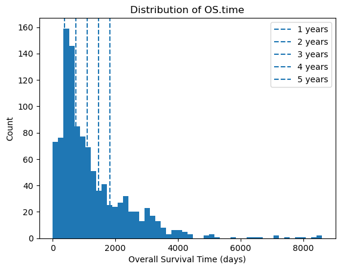

```python
# Follow-up Time Distribution Plot

plt.hist(surv_df["OS.time"], bins=50)

plt.axvline(365, linestyle="--", label="1 years")
plt.axvline(730, linestyle="--", label="2 years")
plt.axvline(1095, linestyle="--", label="3 years")
plt.axvline(1460, linestyle="--", label="4 years")
plt.axvline(1825, linestyle="--", label="5 years")

plt.legend()
plt.xlabel("Overall Survival Time (days)")
plt.ylabel("Count")
plt.title("Distribution of OS.time")
plt.show()
```

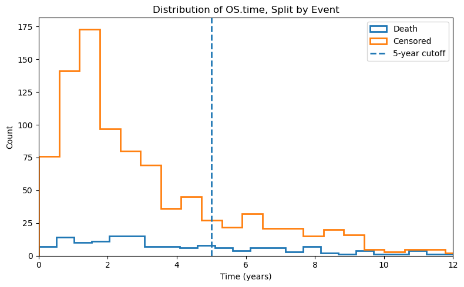

```python
# Follow-up Time Distribution Plot, split by event

# Convert to years
time_years = surv_df["OS.time"] / 365.25

death = time_years[surv_df["OS"] == 1]
censored = time_years[surv_df["OS"] == 0]

plt.figure(figsize=(8, 5))

plt.hist(death, bins=40, histtype="step", linewidth=2, label="Death")
plt.hist(censored, bins=40, histtype="step", linewidth=2, label="Censored")

plt.axvline(5, linestyle="--", linewidth=2, label="5-year cutoff")

plt.xlim(0, 12)  # adjust if needed
plt.xlabel("Time (years)")
plt.ylabel("Count")
plt.title("Distribution of OS.time, Split by Event")
plt.legend()
plt.tight_layout()
plt.show()
```

```python
# How many ≥ 5 years (1825 days)

five_year_days = 1825

n_ge_5y = (surv_df["OS.time"] >= five_year_days).sum()
print("Patients with follow-up ≥ 5 years:", n_ge_5y)
print("Proportion:", round(n_ge_5y / n_total, 3))


# Check how many patients work for a 5 year survival cutoff

died_before_5y = ((surv_df["OS"] == 1) & (surv_df["OS.time"] < five_year_days)).sum()
alive_ge_5y = ((surv_df["OS"] == 0) & (surv_df["OS.time"] >= five_year_days)).sum()
alive_lt_5y = ((surv_df["OS"] == 0) & (surv_df["OS.time"] < five_year_days)).sum()

print("Died <5y:", died_before_5y)
print("Alive ≥5y:", alive_ge_5y)
print("Alive <5y (censored):", alive_lt_5y)
```

```
Patients with follow-up ≥ 5 years: 251
Proportion: 0.233
Died <5y: 100
Alive ≥5y: 201
Alive <5y (censored): 725
```

```python
# How many ≥ 3 years (1825 days)

three_year_days = 1095

n_ge_3y = (surv_df["OS.time"] >= three_year_days).sum()
print("Patients with follow-up ≥ 3 years:", n_ge_3y)
print("Proportion:", round(n_ge_3y / n_total, 3))


# Check how many patients work for a 5 year survival cutoff

died_before_3y = ((surv_df["OS"] == 1) & (surv_df["OS.time"] < three_year_days)).sum()
alive_ge_3y = ((surv_df["OS"] == 0) & (surv_df["OS.time"] >= three_year_days)).sum()
alive_lt_3y = ((surv_df["OS"] == 0) & (surv_df["OS.time"] < three_year_days)).sum()

print("Died <3y:", died_before_3y)
print("Alive ≥3y:", alive_ge_3y)
print("Alive <3y (censored):", alive_lt_3y)
```

```
Patients with follow-up ≥ 3 years: 434
Proportion: 0.403
Died <3y: 71
Alive ≥3y: 355
Alive <3y (censored): 571
```

```python
# Filter to patients useable for 5 year survival end point

five_year_days = 1825

mask_use = (
    ((surv_df["OS"] == 1) & (surv_df["OS.time"] < five_year_days)) |
    ((surv_df["OS"] == 0) & (surv_df["OS.time"] >= five_year_days))
)

surv_df = surv_df.loc[mask_use].copy()

print("Filtered cohort size:", len(surv_df))
```

```
Filtered cohort size: 301
```

### Clinical QC and EDA

- Remove metadata IDs
- Remove high-missing junk
- Remove survival timing leakage
- Remove constant variables
- Review categorical structure
- Review numeric sanity

```python
# Subset to samples present in the filtered survival cohort
clin_df = clin_raw_df[
    clin_raw_df["sample"].isin(surv_df.index)
].copy()

# Move 'sample' to index
clin_df = clin_df.set_index("sample", drop=True)

print("Clinical shape after filtering:", clin_df.shape)

# Sanity check: exact match
print(
    set(clin_df.index) == set(surv_df.index)
)
```

```
Clinical shape after filtering: (301, 84)
True
```

#### Missing-ness profile

**Why We Examine Clinical Missingness Structure**

Before modeling, ask:

**Is clinical missingness structured in a way that could bias modeling or data splitting?**

Specifically:

1. **Is missingness approximately random noise?**  
   → Simple imputation (median/mode) is likely sufficient.
2. **Is missingness cohort-structured?**  
   (e.g., concentrated in a subset of patients)  
   → Consider stratified splitting and/or adding missingness indicators as features.
3. **Are there blocks of patients missing the same variables?**  
   → May indicate data collection phases, subtype-dependent recording, or batch effects.
4. **Are some variables almost always co-missing?**  
   → These variables may be redundant; consider dropping one to reduce dimensionality and instability.

The goal is not to remove samples prematurely, but to understand whether missingness itself carries structure that must be handled explicitly.

**Interpretation**

- Annotation columns (~98–100% missing)
  - These are metadata artifacts from the GDC export.
  - They are not modeling variables.
  - Drop them entirely.
- days_to_sample_procurement.samples (100%)
  - Useless. Drop.
- year_of_death.demographic (78% missing)
  - Expected. Most patients alive or censored.
  - Not useful as a feature. Survival time already encoded elsewhere.
- days_to_death.demographic (67% missing)
  - Also expected in censored cohort.
  - Should not be a feature if you’re predicting survival.

```python
# Missingness profile
# Identify columns >30–40% missing

# Percent missing per column
missing_pct = clin_df.isna().mean().sort_values(ascending=False)

missing_summary = pd.DataFrame({
    "percent_missing": missing_pct * 100
})

display(missing_summary.head(20))

# Identify high-missingness columns
HIGH_MISSING_THRESHOLD = 0.30  # 30%
high_missing_cols = missing_pct[missing_pct > HIGH_MISSING_THRESHOLD].index.tolist()

print(f"Columns >30% missing ({len(high_missing_cols)}):")
print(high_missing_cols)
```

|  | percent_missing |
| --- | --- |
| annotations.samples | 100.000000 |
| days_to_sample_procurement.samples | 100.000000 |
| submitter_id.annotations | 98.006645 |
| notes.annotations | 98.006645 |
| classification.annotations | 98.006645 |
| entity_id.annotations | 98.006645 |
| case_submitter_id.annotations | 98.006645 |
| status.annotations | 98.006645 |
| category.annotations | 98.006645 |
| state.annotations | 98.006645 |
| updated_datetime.annotations | 98.006645 |
| case_id.annotations | 98.006645 |
| entity_type.annotations | 98.006645 |
| entity_submitter_id.annotations | 98.006645 |
| created_datetime.annotations | 98.006645 |
| annotation_id.annotations | 98.006645 |
| year_of_death.demographic | 77.740864 |
| days_to_death.demographic | 67.109635 |
| days_to_last_follow_up.diagnoses | 22.259136 |
| ajcc_staging_system_edition.diagnoses | 9.302326 |

```
Columns >30% missing (18):
['annotations.samples', 'days_to_sample_procurement.samples', 'submitter_id.annotations', 'notes.annotations', 'classification.annotations', 'entity_id.annotations', 'case_submitter_id.annotations', 'status.annotations', 'category.annotations', 'state.annotations', 'updated_datetime.annotations', 'c…
```

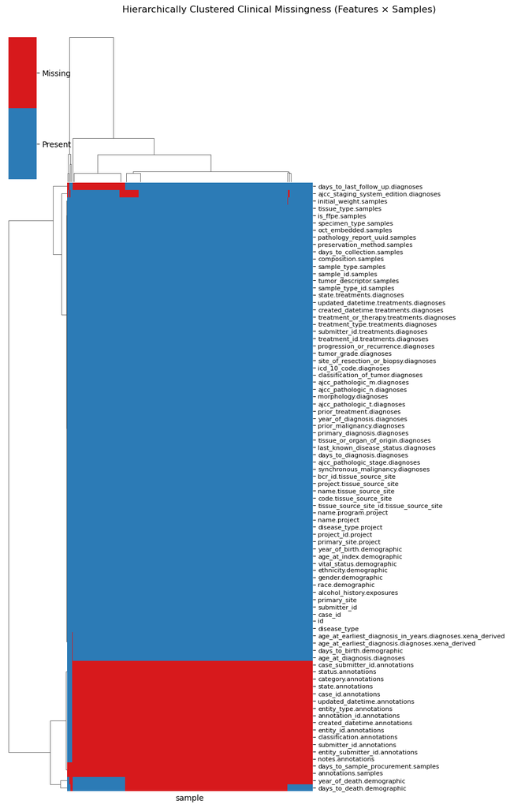

```python
# Missingness profile heatmap

# Transpose so rows = features, columns = samples
M = clin_df.isna().astype(int).T

binary_cmap = ListedColormap(["#2c7bb6", "#d7191c"])

g = sns.clustermap(
    M,
    metric="hamming",
    method="average",
    cmap=binary_cmap,
    vmin=0, vmax=1,
    xticklabels=False,      # too many samples
    yticklabels=True,       # show feature names
    figsize=(10, 14)
)

# Improve feature label readability
g.ax_heatmap.set_yticklabels(
    g.ax_heatmap.get_yticklabels(),
    fontsize=8
)

g.cax.set_yticks([0.25, 0.75])
g.cax.set_yticklabels(["Present", "Missing"])
g.cax.set_ylabel("")
g.fig.suptitle("Hierarchically Clustered Clinical Missingness (Features × Samples)", y=1.02)

plt.show()
```

```python
# Drop high-missing columns
missing_threshold = 0.30
cols_to_drop = missing_pct[missing_pct > missing_threshold].index

clin_df = clin_df.drop(columns=cols_to_drop)

print(f"Dropped {len(cols_to_drop)} high-missing columns")
```

```
Dropped 18 high-missing columns
```

#### Value sanity checks

**Categories to drop at this stage:**

1. Structural artifacts
- IDs
- UUIDs
- Datetime fields
- Annotation exports
2. Degenerate variables
- Constant columns
- All zeros
- No variance
3. Pure survival metadata
- Anything encoding follow-up time, death timing, or derived outcome

**Categorical: unexpected levels, typos, near constant variables, rare levels**

- Identified ID like columns, can drop
- Also identified variables that are data base entry time
- If a variable represents when the record was created or updated, not when the patient event occurred, drop it.
  - Drop because the model can learn era effects instead of biology.
    - They reflect database entry timing, not clinical state
    - They often correlate with submission wave or processing batch
    - They can act as a proxy for calendar time
    - That introduces temporal leakage or cohort drift

```python
# Categorical value sanity checks

cat_cols = clin_df.select_dtypes(exclude=["number"]).columns

cat_summary = []

for col in cat_cols:
    vc = clin_df[col].value_counts(dropna=False)
    vc_norm = clin_df[col].value_counts(normalize=True, dropna=False)

    top5 = vc.head(5).index.tolist()

    cat_summary.append({
        "variable": col,
        "n_unique": clin_df[col].nunique(dropna=True),
        "percent_missing": clin_df[col].isna().mean() * 100,
        "top_5_levels": top5,
        "n_rare_levels_<1pct": (vc_norm < 0.01).sum()
    })

cat_summary_df = pd.DataFrame(cat_summary).sort_values(
    by="n_rare_levels_<1pct", ascending=False
)

with pd.option_context("display.max_rows", None,
                       "display.max_colwidth", None):
    display(cat_summary_df)
```

|  | variable | n_unique | percent_missing | top_5_levels | n_rare_levels_<1pct |
| --- | --- | --- | --- | --- | --- |
| 0 | id | 301 | 0.000000 | [623befd6-0ca4-4a6c-9cf5-d9385c3b718f, 3cb06c7a-f2a8-448b-91a8-dd201bbf2ddd, ac6d3ba9-f84f-4657-aa85-4d66fb7c09da, b0700958-5f90-4546-b35f-635cd506889b, b1d44c81-747d-471f-9093-aeb262a17975] | 301 |
| 2 | case_id | 301 | 0.000000 | [623befd6-0ca4-4a6c-9cf5-d9385c3b718f, 3cb06c7a-f2a8-448b-91a8-dd201bbf2ddd, ac6d3ba9-f84f-4657-aa85-4d66fb7c09da, b0700958-5f90-4546-b35f-635cd506889b, b1d44c81-747d-471f-9093-aeb262a17975] | 301 |
| 3 | submitter_id | 301 | 0.000000 | [TCGA-AR-A1AO, TCGA-AR-A24V, TCGA-A2-A1FX, TCGA-PE-A5DD, TCGA-Z7-A8R6] | 301 |
| 41 | created_datetime.treatments.diagnoses | 301 | 0.000000 | [['2019-04-28T13:52:43.638722-05:00', ''], ['', '2019-04-28T13:48:27.178841-05:00'], ['', '2019-04-28T13:38:54.663503-05:00'], ['', '2019-04-28T14:01:25.257011-05:00'], ['', '2019-04-28T14:01:33.01729… | 301 |
| 45 | sample_id.samples | 301 | 0.000000 | [5cedca81-7593-48c9-8bed-ebd294347ce7, 49bfd2cc-fddd-4376-8e53-8008ca075779, 71e87611-903b-4b9d-a506-87e58914dc81, 723a715f-02aa-4708-bb61-84a36792ec83, 515600aa-a11b-4630-b88d-c59082ed1684] | 301 |
| 37 | treatment_id.treatments.diagnoses | 301 | 0.000000 | [['12316985-2b62-5237-81b3-36b950d7d05d', 'c5332548-e6cb-5dfc-99d4-406578633939'], ['604fbdb7-b807-535d-9cfd-f40a10bace82', 'c21f5efb-7db8-5f21-812e-7630a6bb8dbe'], ['a35e05cb-8b7c-51d9-aebe-af028d890… | 301 |
| 49 | pathology_report_uuid.samples | 301 | 0.000000 | [37EF1828-0A53-4358-97C7-A7849EC653AF, 468CD293-C9F7-43C6-A40A-18FCDD22F6AA, EAFC71A1-D6FC-46EA-BC47-D054C497D705, 7A2719FC-1CA2-4D58-9EF7-594926D1FF66, 9A5C8EDF-9243-4F55-9036-A400CF3F4CC1] | 301 |
| 42 | updated_datetime.treatments.diagnoses | 301 | 0.000000 | [['2019-07-31T21:42:58.764753-05:00', '2019-07-31T21:42:58.764753-05:00'], ['2019-07-31T21:37:39.828126-05:00', '2019-07-31T21:37:39.828126-05:00'], ['2019-07-31T21:25:39.755209-05:00', '2019-07-31T21… | 301 |
| 38 | submitter_id.treatments.diagnoses | 301 | 0.000000 | [['TCGA-AR-A1AO_treatment_1', 'TCGA-AR-A1AO_treatment'], ['TCGA-AR-A24V_treatment', 'TCGA-AR-A24V_treatment_1'], ['TCGA-A2-A1FX_treatment', 'TCGA-A2-A1FX_treatment_1'], ['TCGA-PE-A5DD_treatment', 'TCG… | 301 |
| 15 | tissue_source_site_id.tissue_source_site | 24 | 0.000000 | [ad5db77f-ce9a-53c8-b7ff-7944acf5c0c6, 5e793cf6-1554-55db-b2ee-9c772717cea0, 2acf08ea-28f9-5bc2-a6cf-bf8ce719ce29, fac53f4f-307f-5e32-942f-5755959ac426, 42876508-d6c1-55cd-8749-434537899294] | 14 |
| 17 | name.tissue_source_site | 24 | 0.000000 | [University of Pittsburgh, Mayo, Walter Reed, Duke, MSKCC] | 14 |
| 16 | code.tissue_source_site | 24 | 0.000000 | [BH, AR, A2, B6, AO] | 14 |
| 24 | primary_diagnosis.diagnoses | 13 | 0.000000 | [Infiltrating duct carcinoma, NOS, Lobular carcinoma, NOS, Infiltrating duct and lobular carcinoma, Infiltrating duct mixed with other types of carcinoma, Metaplastic carcinoma, NOS] | 9 |
| 29 | morphology.diagnoses | 13 | 0.000000 | [8500/3, 8520/3, 8522/3, 8523/3, 8575/3] | 9 |
| 1 | disease_type | 6 | 0.000000 | [Ductal and Lobular Neoplasms, Epithelial Neoplasms, NOS, Complex Epithelial Neoplasms, Cystic, Mucinous and Serous Neoplasms, Squamous Cell Neoplasms] | 5 |
| 28 | ajcc_pathologic_t.diagnoses | 11 | 0.000000 | [T2, T1c, T3, T1, T4b] | 5 |
| 40 | treatment_or_therapy.treatments.diagnoses | 9 | 0.000000 | [['yes', 'yes'], ['no', 'yes'], ['yes', 'no'], ['not reported', 'not reported'], ['no', 'no']] | 4 |
| 21 | ajcc_pathologic_stage.diagnoses | 12 | 0.000000 | [Stage IIA, Stage IIB, Stage IIIA, Stage I, Stage IA] | 3 |
| 34 | site_of_resection_or_biopsy.diagnoses | 4 | 0.000000 | [Breast, NOS, Overlapping lesion of breast, Upper-outer quadrant of breast, Lower-inner quadrant of breast] | 3 |
| 33 | icd_10_code.diagnoses | 4 | 0.000000 | [C50.9, C50.8, C50.4, C50.3] | 3 |
| 23 | tissue_or_organ_of_origin.diagnoses | 4 | 0.000000 | [Breast, NOS, Overlapping lesion of breast, Upper-outer quadrant of breast, Lower-inner quadrant of breast] | 3 |
| 30 | ajcc_pathologic_n.diagnoses | 15 | 0.000000 | [N0, N0 (i-), N1a, N1, N2a] | 3 |
| 31 | ajcc_pathologic_m.diagnoses | 4 | 0.000000 | [M0, MX, M1, cM0 (i+)] | 1 |
| 19 | bcr_id.tissue_source_site | 1 | 0.000000 | [NCH] | 0 |
| 20 | synchronous_malignancy.diagnoses | 2 | 0.000000 | [No, Not Reported] | 0 |
| 14 | name.program.project | 1 | 0.000000 | [TCGA] | 0 |
| 10 | primary_site.project | 1 | 0.000000 | [Breast] | 0 |
| 11 | project_id.project | 1 | 0.000000 | [TCGA-BRCA] | 0 |
| 18 | project.tissue_source_site | 1 | 0.000000 | [Breast invasive carcinoma] | 0 |
| 13 | name.project | 1 | 0.000000 | [Breast Invasive Carcinoma] | 0 |
| 9 | vital_status.demographic | 2 | 0.000000 | [Alive, Dead] | 0 |
| 8 | ethnicity.demographic | 3 | 0.000000 | [not hispanic or latino, not reported, hispanic or latino] | 0 |
| 7 | gender.demographic | 2 | 0.000000 | [female, male] | 0 |
| 6 | race.demographic | 4 | 0.000000 | [white, black or african american, asian, not reported] | 0 |
| 4 | primary_site | 1 | 0.000000 | [Breast] | 0 |
| 5 | alcohol_history.exposures | 1 | 0.000000 | [Not Reported] | 0 |
| 12 | disease_type.project | 1 | 0.000000 | [['Squamous Cell Neoplasms', 'Adnexal and Skin Appendage Neoplasms', 'Epithelial Neoplasms, NOS', 'Complex Epithelial Neoplasms', 'Fibroepithelial Neoplasms', 'Cystic, Mucinous and Serous Neoplasms', … | 0 |
| 27 | ajcc_staging_system_edition.diagnoses | 5 | 9.302326 | [6th, 5th, 7th, nan, 4th] | 0 |
| 36 | progression_or_recurrence.diagnoses | 1 | 0.000000 | [not reported] | 0 |
| 35 | tumor_grade.diagnoses | 1 | 0.000000 | [Not Reported] | 0 |
| 32 | classification_of_tumor.diagnoses | 1 | 0.000000 | [not reported] | 0 |
| 26 | prior_treatment.diagnoses | 2 | 0.000000 | [No, Yes] | 0 |
| 25 | prior_malignancy.diagnoses | 2 | 0.000000 | [no, yes] | 0 |
| 22 | last_known_disease_status.diagnoses | 1 | 0.000000 | [not reported] | 0 |
| 43 | state.treatments.diagnoses | 1 | 0.000000 | [['released', 'released']] | 0 |
| 39 | treatment_type.treatments.diagnoses | 2 | 0.000000 | [['Pharmaceutical Therapy, NOS', 'Radiation Therapy, NOS'], ['Radiation Therapy, NOS', 'Pharmaceutical Therapy, NOS']] | 0 |
| 44 | tumor_descriptor.samples | 1 | 0.000000 | [Primary] | 0 |
| 46 | sample_type.samples | 1 | 0.000000 | [Primary Tumor] | 0 |
| 47 | composition.samples | 1 | 0.000000 | [Not Reported] | 0 |
| 48 | preservation_method.samples | 2 | 0.000000 | [OCT, Unknown] | 0 |
| 50 | oct_embedded.samples | 2 | 0.000000 | [True, False] | 0 |
| 51 | specimen_type.samples | 1 | 0.000000 | [Solid Tissue] | 0 |
| 52 | is_ffpe.samples | 1 | 0.000000 | [False] | 0 |
| 53 | tissue_type.samples | 1 | 0.000000 | [Tumor] | 0 |

```python
# Drop the ID columns

print('Shape before:', clin_df.shape)
id_like_cols = [
    col for col in clin_df.columns
    if clin_df[col].nunique(dropna=False) == clin_df.shape[0]
]

print(f"Found {len(id_like_cols)} ID-like cols")
print(id_like_cols)

clin_df = clin_df.drop(columns=id_like_cols)

print('Shape after:', clin_df.shape)
```

```
Shape before: (301, 66)
Found 9 ID-like cols
['id', 'case_id', 'submitter_id', 'treatment_id.treatments.diagnoses', 'submitter_id.treatments.diagnoses', 'created_datetime.treatments.diagnoses', 'updated_datetime.treatments.diagnoses', 'sample_id.samples', 'pathology_report_uuid.samples']
Shape after: (301, 57)
```

#### Numeric sanity checks

- Look for impossible values (e.g., negative age in years, implausible age >120)
- Identify extreme outliers requiring review (not automatic removal)

**DROP: Survival timing fields** (Contain outcome signal and would introduce leakage)

- days_to_last_follow_up.diagnoses

**Drop: Degenerate variables**

- days_to_diagnosis.diagnoses (all zeros)
- sample_type_id.samples (constant)

```python
# Numeric value sanity checks

num_cols = clin_df.select_dtypes(include=["number"]).columns

num_summary = clin_df[num_cols].describe().T

# Add extreme quantiles
quantiles = clin_df[num_cols].quantile([0.01, 0.99]).T
quantiles.columns = ["p01", "p99"]

num_summary = num_summary.join(quantiles)

with pd.option_context("display.max_rows", None):
    display(num_summary)
```

|  | count | mean | std | min | 25% | 50% | 75% | max | p01 | p99 |
| --- | --- | --- | --- | --- | --- | --- | --- | --- | --- | --- |
| age_at_index.demographic | 301.0 | 56.647841 | 13.353735 | 26.000000 | 47.000000 | 56.000000 | 64.000000 | 90.000000 | 29.000000 | 88.000000 |
| days_to_birth.demographic | 300.0 | -20890.880000 | 4869.730835 | -32871.000000 | -23728.250000 | -20650.000000 | -17358.750000 | -9840.000000 | -32296.090000 | -10895.180000 |
| year_of_birth.demographic | 301.0 | 1948.046512 | 13.710258 | 1909.000000 | 1939.000000 | 1949.000000 | 1958.000000 | 1979.000000 | 1916.000000 | 1974.000000 |
| days_to_diagnosis.diagnoses | 301.0 | 0.000000 | 0.000000 | 0.000000 | 0.000000 | 0.000000 | 0.000000 | 0.000000 | 0.000000 | 0.000000 |
| days_to_last_follow_up.diagnoses | 234.0 | 2624.717949 | 1437.413879 | 1.000000 | 2022.000000 | 2459.500000 | 3126.250000 | 8605.000000 | 6.950000 | 8264.610000 |
| age_at_diagnosis.diagnoses | 300.0 | 20890.880000 | 4869.730835 | 9840.000000 | 17358.750000 | 20650.000000 | 23728.250000 | 32871.000000 | 10895.180000 | 32296.090000 |
| year_of_diagnosis.diagnoses | 301.0 | 2004.694352 | 4.574524 | 1988.000000 | 2003.000000 | 2006.000000 | 2007.000000 | 2013.000000 | 1990.000000 | 2013.000000 |
| age_at_earliest_diagnosis.diagnoses.xena_derived | 300.0 | 20890.880000 | 4869.730835 | 9840.000000 | 17358.750000 | 20650.000000 | 23728.250000 | 32871.000000 | 10895.180000 | 32296.090000 |
| age_at_earliest_diagnosis_in_years.diagnoses.xena_derived | 300.0 | 57.235288 | 13.341728 | 26.958904 | 47.558219 | 56.575342 | 65.008904 | 90.057534 | 29.849808 | 88.482438 |
| sample_type_id.samples | 301.0 | 1.000000 | 0.000000 | 1.000000 | 1.000000 | 1.000000 | 1.000000 | 1.000000 | 1.000000 | 1.000000 |
| days_to_collection.samples | 301.0 | 2152.790698 | 1597.298452 | 22.000000 | 1157.000000 | 1744.000000 | 2709.000000 | 7820.000000 | 38.000000 | 7290.000000 |
| initial_weight.samples | 300.0 | 301.783333 | 234.650319 | 5.000000 | 140.000000 | 230.000000 | 412.500000 | 1360.000000 | 19.900000 | 1050.500000 |

```python
# Filter clinical data numeric columns

# Columns to drop
cols_to_drop = [
    "days_to_diagnosis.diagnoses",
    "sample_type_id.samples",
    "days_to_last_follow_up.diagnoses"
]

print("Shape before:", clin_df.shape)

# Drop only if they exist (safe guard)
cols_to_drop = [c for c in cols_to_drop if c in clin_df.columns]

clin_df = clin_df.drop(columns=cols_to_drop)

print("Dropped columns:", cols_to_drop)
print("Shape after:", clin_df.shape)
```

```
Shape before: (301, 57)
Dropped columns: ['days_to_diagnosis.diagnoses', 'sample_type_id.samples', 'days_to_last_follow_up.diagnoses']
Shape after: (301, 54)
```

### RNA-seq EDA

```python
cohort_cols = ["Ensembl_ID"] + rna_raw_df.columns.intersection(surv_df.index).tolist()
rna_df = rna_raw_df.loc[:, cohort_cols]

print("RNA shape before:", rna_raw_df.shape)
print("RNA shape after filtering:", rna_df.shape)
```

```
RNA shape before: (60660, 1227)
RNA shape after filtering: (60660, 301)
```

```python
# Set gene IDs as index (no duplication of matrix)
rna_df = rna_df.set_index("Ensembl_ID", drop=True)
```

```python
rna_df
```

| Ensembl_ID | TCGA-AQ-A0Y5-01A | TCGA-AC-A62V-01A | TCGA-AO-A0J5-01A | TCGA-AO-A03N-01B | TCGA-AO-A1KQ-01A | TCGA-E2-A1LI-01A | TCGA-E2-A1LE-01A | TCGA-A2-A0CO-01A | TCGA-BH-A0BM-01A | TCGA-AR-A0TW-01A | ... | TCGA-AR-A1AU-01A | TCGA-E2-A1L7-01A | TCGA-AR-A0U0-01A | TCGA-A8-A06U-01A | TCGA-BH-A18L-01A | TCGA-AR-A24T-01A | TCGA-E2-A1IG-01A | TCGA-AR-A252-01A | TCGA-BH-A0EI-01A | TCGA-E2-A1IO-01A |
| --- | --- | --- | --- | --- | --- | --- | --- | --- | --- | --- | --- | --- | --- | --- | --- | --- | --- | --- | --- | --- | --- |
| ENSG00000000003.15 | 3.703721 | 3.536849 | 4.645690 | 3.613025 | 3.814632 | 5.451000 | 5.194666 | 4.757157 | 6.067475 | 3.920198 | ... | 4.571653 | 5.064572 | 4.572532 | 4.910627 | 3.551614 | 5.737154 | 4.825501 | 4.770121 | 6.436490 | 6.184500 |
| ENSG00000000005.6 | 0.463099 | 0.736475 | 1.255622 | 0.000000 | 0.196733 | 3.481234 | 2.656405 | 2.745001 | 3.316826 | 0.187134 | ... | 2.400920 | 0.959844 | 0.000000 | 0.000000 | 0.697062 | 0.334339 | 0.134747 | 3.312418 | 0.383608 | 0.755144 |
| ENSG00000000419.13 | 7.086452 | 6.823355 | 5.749910 | 6.079559 | 7.297865 | 7.137935 | 6.343246 | 6.145796 | 5.983919 | 6.879327 | ... | 6.400727 | 7.041613 | 6.816136 | 7.625283 | 7.125996 | 6.757538 | 6.382933 | 6.005000 | 7.220846 | 6.868277 |
| ENSG00000000457.14 | 4.051007 | 2.108324 | 4.487107 | 2.287502 | 3.590554 | 4.518434 | 5.266539 | 3.763953 | 3.961549 | 4.102507 | ... | 3.951858 | 3.898063 | 3.232492 | 3.229772 | 4.832865 | 4.103389 | 3.891448 | 3.648707 | 3.752192 | 4.093078 |
| ENSG00000000460.17 | 2.426989 | 2.277777 | 2.545178 | 1.753177 | 3.022616 | 4.669786 | 3.417704 | 1.966652 | 1.868687 | 1.388355 | ... | 2.709357 | 3.516280 | 2.915769 | 2.754417 | 3.630429 | 2.953824 | 2.557655 | 2.494160 | 3.111549 | 2.538538 |
| ... | ... | ... | ... | ... | ... | ... | ... | ... | ... | ... | ... | ... | ... | ... | ... | ... | ... | ... | ... | ... | ... |
| ENSG00000288669.1 | 0.000000 | 0.000000 | 0.000000 | 0.000000 | 0.000000 | 0.000000 | 0.022190 | 0.000000 | 0.000000 | 0.000000 | ... | 0.000000 | 0.000000 | 0.000000 | 0.000000 | 0.000000 | 0.023042 | 0.000000 | 0.000000 | 0.000000 | 0.000000 |
| ENSG00000288670.1 | 4.773448 | 3.140910 | 3.471331 | 1.934517 | 3.430767 | 3.989130 | 2.998918 | 3.562010 | 3.903800 | 3.608715 | ... | 4.328090 | 3.573435 | 3.645667 | 2.754652 | 4.651540 | 4.190078 | 4.779218 | 3.122010 | 4.015756 | 3.535331 |
| ENSG00000288671.1 | 0.000000 | 0.000000 | 0.000000 | 0.000000 | 0.000000 | 0.000000 | 0.000000 | 0.000000 | 0.000000 | 0.000000 | ... | 0.000000 | 0.000000 | 0.000000 | 0.000000 | 0.000000 | 0.000000 | 0.000000 | 0.000000 | 0.000000 | 0.000000 |
| ENSG00000288674.1 | 0.054779 | 0.071900 | 0.051581 | 0.000000 | 0.052972 | 0.037031 | 0.054501 | 0.131853 | 0.022758 | 0.015212 | ... | 0.068877 | 0.088684 | 0.047957 | 0.064883 | 0.033934 | 0.074916 | 0.032101 | 0.047678 | 0.044324 | 0.074231 |
| ENSG00000288675.1 | 1.243182 | 1.212071 | 1.049979 | 1.498710 | 1.049213 | 0.939678 | 1.214809 | 0.802317 | 0.495388 | 1.002739 | ... | 0.971148 | 0.552967 | 1.032171 | 0.219711 | 0.095182 | 0.581496 | 0.991898 | 0.866631 | 1.381560 | 0.864018 |

60660 rows × 300 columns

```python
# Sample-level QC metrics
qc_df = pd.DataFrame({
    "mean_expr": rna_df.mean(axis=0),
    "median_expr": rna_df.median(axis=0),
    "sd_expr": rna_df.std(axis=0),
    "detected_genes": (rna_df > 0).sum(axis=0),
    "percent_zeros": (rna_df == 0).sum(axis=0) / rna_df.shape[0]
})

qc_df
```

|  | mean_expr | median_expr | sd_expr | detected_genes | percent_zeros |
| --- | --- | --- | --- | --- | --- |
| TCGA-AQ-A0Y5-01A | 1.167079 | 0.068602 | 1.998165 | 32629 | 0.462100 |
| TCGA-AC-A62V-01A | 1.055439 | 0.000000 | 1.955383 | 29648 | 0.511243 |
| TCGA-AO-A0J5-01A | 1.180436 | 0.074231 | 2.008713 | 33431 | 0.448879 |
| TCGA-AO-A03N-01B | 0.833770 | 0.000000 | 1.602100 | 26053 | 0.570508 |
| TCGA-AO-A1KQ-01A | 1.155044 | 0.073957 | 1.949395 | 32549 | 0.463419 |
| ... | ... | ... | ... | ... | ... |
| TCGA-AR-A24T-01A | 1.251443 | 0.116099 | 2.047498 | 34000 | 0.439499 |
| TCGA-E2-A1IG-01A | 1.183863 | 0.044394 | 2.013641 | 31389 | 0.482542 |
| TCGA-AR-A252-01A | 1.188433 | 0.114900 | 1.955514 | 35296 | 0.418134 |
| TCGA-BH-A0EI-01A | 1.252786 | 0.059632 | 2.064537 | 31656 | 0.478140 |
| TCGA-E2-A1IO-01A | 1.273338 | 0.096802 | 2.062318 | 33007 | 0.455869 |

300 rows × 5 columns

#### Sample-Level RNA-seq QC: What to Look For

- **mean_expr**
  - Expression outliers
  - Extreme low-mean samples suggesting poor library complexity
- **median_expr**
  - Expression outliers
  - Unexpected shift away from near-zero median (distribution distortion)
- **sd_expr**
  - Low SD indicating compressed or low dynamic range libraries
  - High SD suggesting unstable or noisy profiles
- **detected_genes**
  - Left-tail samples with substantially fewer detected genes
  - Extreme high outliers
- **percent_zeros**
  - Overall cohort sparsity pattern
  - Right-tail outliers with excessive sparsity

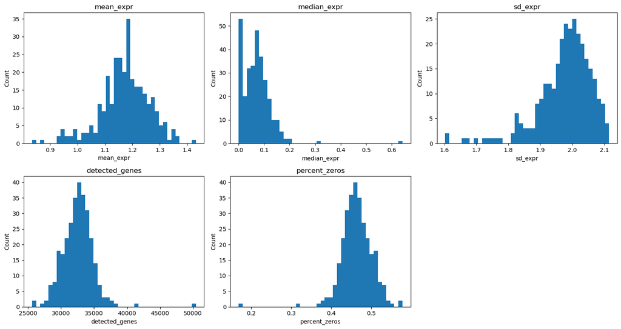

```python
# Sample-Level RNA-seq QC

metrics = qc_df.columns
n_metrics = len(metrics)

fig, axes = plt.subplots(2, 3, figsize=(15, 8))
axes = axes.flatten()

for i, metric in enumerate(metrics):
    axes[i].hist(qc_df[metric], bins=40)
    axes[i].set_title(metric)
    axes[i].set_xlabel(metric)
    axes[i].set_ylabel("Count")

# Hide any unused subplot (since we have 5 metrics)
for j in range(i + 1, len(axes)):
    axes[j].axis("off")

plt.tight_layout()
plt.show()
```

```python
# Are the outliers on each graph the same sample for multiple metrics?

# Define outliers as extreme 1% tails
outlier_flags = pd.DataFrame(index=qc_df.index)

for col in qc_df.columns:
    lower = qc_df[col].quantile(0.01)
    upper = qc_df[col].quantile(0.99)
    outlier_flags[col] = (qc_df[col] < lower) | (qc_df[col] > upper)

# Count how many metrics each sample is extreme in
outlier_flags["n_outlier_metrics"] = outlier_flags.sum(axis=1)

# Samples extreme in >=2 metrics
multi_metric_outliers = outlier_flags[outlier_flags["n_outlier_metrics"] >= 2]

multi_metric_outliers.sort_values("n_outlier_metrics", ascending=False)
```

|  | mean_expr | median_expr | sd_expr | detected_genes | percent_zeros | n_outlier_metrics |
| --- | --- | --- | --- | --- | --- | --- |
| TCGA-AO-A03N-01B | True | False | True | True | True | 4 |
| TCGA-E9-A245-01A | True | True | False | True | True | 4 |
| TCGA-A7-A13E-01A | False | True | False | True | True | 3 |
| TCGA-AO-A03T-01A | True | False | True | False | False | 2 |
| TCGA-GM-A2DH-01A | True | False | True | False | False | 2 |
| TCGA-BH-A1EU-01A | True | True | False | False | False | 2 |
| TCGA-A2-A04P-01A | True | False | True | False | False | 2 |
| TCGA-E9-A226-01A | False | False | False | True | True | 2 |
| TCGA-UU-A93S-01A | False | False | False | True | True | 2 |
| TCGA-AR-A251-01A | False | False | False | True | True | 2 |

```python
# Filter RNAseq matrix

# Defined outliers as extreme 1% tails
# Remove samples extreme in >=2 metrics
samples_to_remove = outlier_flags[
    outlier_flags["n_outlier_metrics"] >= 2
].index

print(f"Removing {len(samples_to_remove)} samples:")
print(samples_to_remove.tolist())

print('Shape before removal')
display(rna_df.shape)
rna_df = rna_df.drop(columns=samples_to_remove)
print('Shape after removal')
display(rna_df.shape)
```

```
Removing 10 samples:
['TCGA-AO-A03N-01B', 'TCGA-AO-A03T-01A', 'TCGA-BH-A1EU-01A', 'TCGA-GM-A2DH-01A', 'TCGA-A7-A13E-01A', 'TCGA-A2-A04P-01A', 'TCGA-E9-A245-01A', 'TCGA-E9-A226-01A', 'TCGA-UU-A93S-01A', 'TCGA-AR-A251-01A']
Shape before removal
```

```
(60660, 300)
```

```
Shape after removal
```

```
(60660, 290)
```

#### Check expression correlation

- **Is overall correlation high?**
  - Bulk RNA-seq samples from human tumors should show generally high pairwise correlation.
  - If most correlations are ~0.85–0.98, that’s normal.
  - If many are <0.7, something is wrong (normalization issue, mixed data types, etc.).
- **Are there strong correlation blocks?**
  - Large blocks along the diagonal suggest shared structure:
    - Cancer subtype
    - Hidden batch
    - Technical processing group

```python
# Rough check for duplicated samples using correlation

# Compute sample–sample Pearson correlation
corr_matrix = rna_df.corr(method="pearson")

# Find near-identical pairs (excluding self-correlation)
threshold = 0.999
duplicates = []

for i in range(len(corr_matrix.columns)):
    for j in range(i + 1, len(corr_matrix.columns)):
        if corr_matrix.iloc[i, j] > threshold:
            duplicates.append(
                (corr_matrix.columns[i], corr_matrix.columns[j],
                 corr_matrix.iloc[i, j])
            )

print("Near-duplicate pairs:")
for d in duplicates:
    print(d)
```

```
Near-duplicate pairs:
```

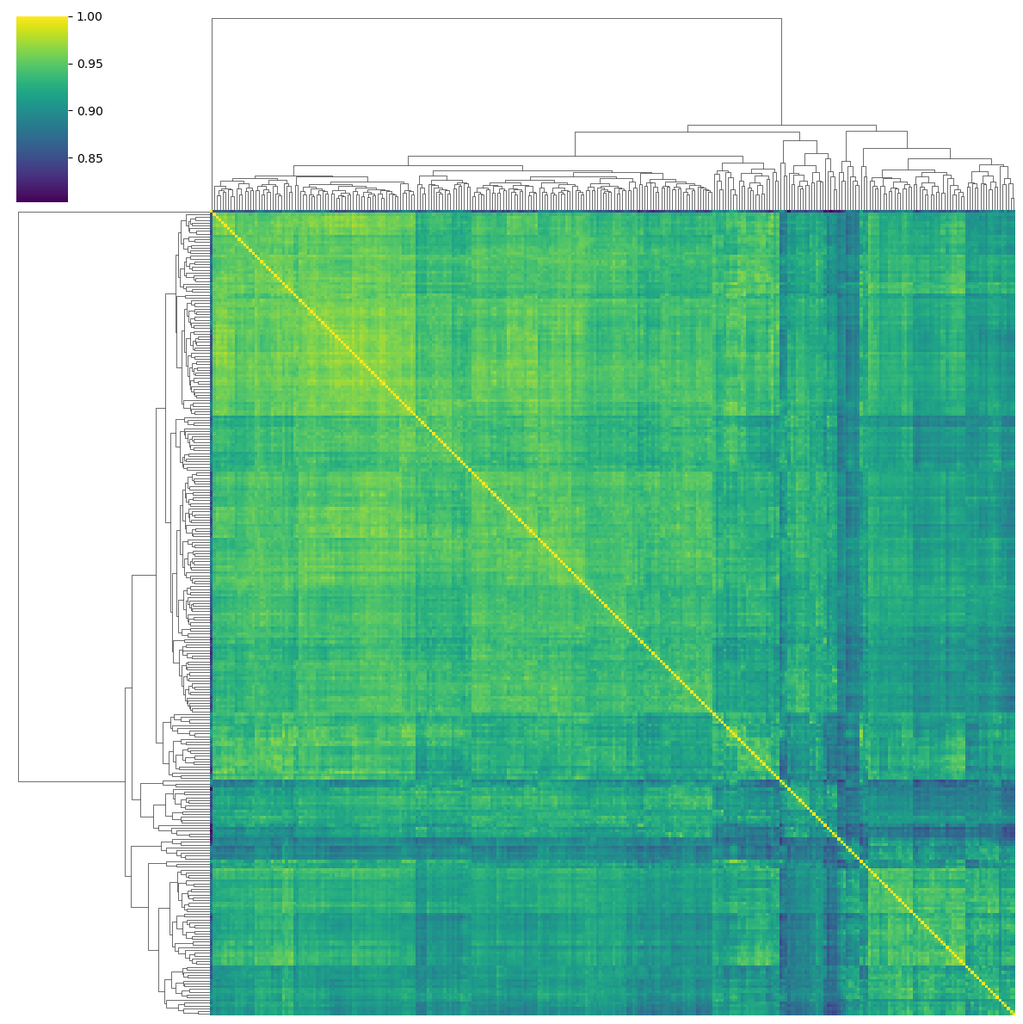

```python
# Plot correlation matrix

plt.figure(figsize=(10, 8))
sns.clustermap(
    corr_matrix,
    cmap="viridis",
    figsize=(12, 12),
    xticklabels=False,
    yticklabels=False
)
plt.show()
```

```python
# Check that one lower correlation sample
# It's a mean correlation of 0.86, the next closest is 0.88, so it's a bit of an outlier but that's still high correlation - keep it
mean_corr = corr_matrix.mean(axis=0)
mean_corr.sort_values()
```

```
TCGA-AC-A2QJ-01A    0.864410
TCGA-A2-A3XU-01A    0.886017
TCGA-A1-A0SK-01A    0.888350
TCGA-V7-A7HQ-01A    0.891483
TCGA-E2-A1LK-01A    0.894665
                      ...
TCGA-A2-A04N-01A    0.942925
TCGA-BH-A0H3-01A    0.942962
TCGA-A2-A25A-01A    0.943131
TCGA-BH-A0BQ-01A    0.943223
TCGA-BH-A0DT-01A    0.946070
Length: 290, dtype: float64
```

#### Basic distribution checks for genes

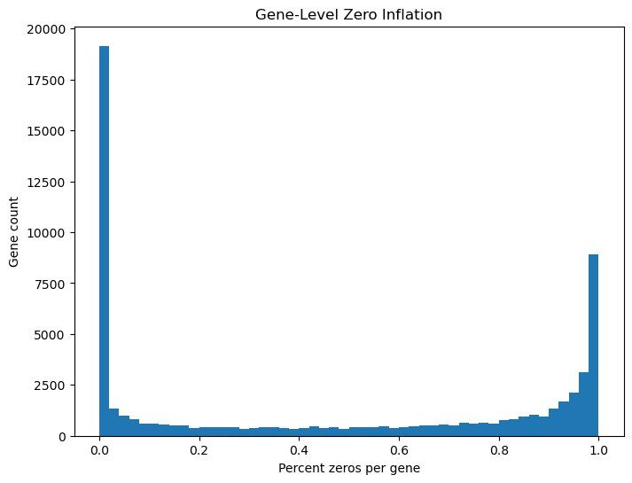

```
0.50    0.444828
0.75    0.927586
0.90    0.993103
0.95    1.000000
0.99    1.000000
dtype: float64
```

```python
# Percent zeros per gene

# What to expect:
# Bimodal distribution
# Large mass near high zero fraction (many genes rarely expressed).

gene_percent_zeros = (rna_df == 0).sum(axis=1) / rna_df.shape[1]

plt.figure(figsize=(8,6))
plt.hist(gene_percent_zeros, bins=50)
plt.xlabel("Percent zeros per gene")
plt.ylabel("Gene count")
plt.title("Gene-Level Zero Inflation")
plt.show()

# Quick summary
gene_percent_zeros.quantile([0.5, 0.75, 0.9, 0.95, 0.99])
```

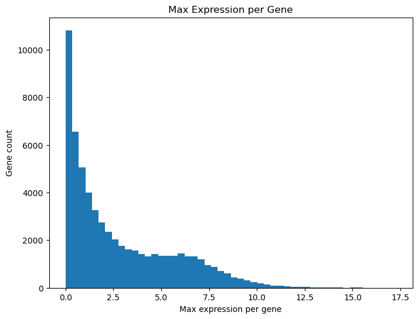

```
Ensembl_ID
ENSG00000211592.8     17.267480
ENSG00000159763.4     16.917957
ENSG00000124935.4     16.618061
ENSG00000198938.2     15.985453
ENSG00000210082.2     15.980333
ENSG00000163220.11    15.962754
ENSG00000198886.2     15.926417
ENSG00000198840.2     15.820402
ENSG00000198712.1     15.804347
ENSG00000198888.2     15.729046
dtype: float64
```

```python
# Max expression per gene

# What to look for:
# A few genes far beyond the rest.
# Possible causes:
# Ribosomal genes
# Mito genes
# Annotation duplicates
# Parsing issues

# What we see:
# • Heavy right skew — expected
# • Large mass of low-max genes — most genes are weakly expressed
# • Smooth decay into a long tail
# • No obvious discontinuities or spikes

gene_max = rna_df.max(axis=1)

plt.figure(figsize=(8,6))
plt.hist(gene_max, bins=50)
plt.xlabel("Max expression per gene")
plt.ylabel("Gene count")
plt.title("Max Expression per Gene")
plt.show()

# Inspect extreme tail - in a more thorough expression analysis we would want to sync these to symbols via ensembl to make sure they make some sense
gene_max.sort_values(ascending=False).head(10)
```